# Easy Test for iregnet on CRAN

Ao Ni

2019/3/12

```r
library(iregnet)
library(glmnet)
library(lasso2)
library(ggplot2)
library(penaltyLearning)
library(rmarkdown)
library(microbenchmark)
data("Prostate")
data('neuroblastomaProcessed')
```

## Introduction

Hello everyone, this is Ao Ni, a senior student major in Statistics who will pursue a master degree in Computer science in the near future.Here is my solution for iregnet on CRAN Tests.

### Test the two function

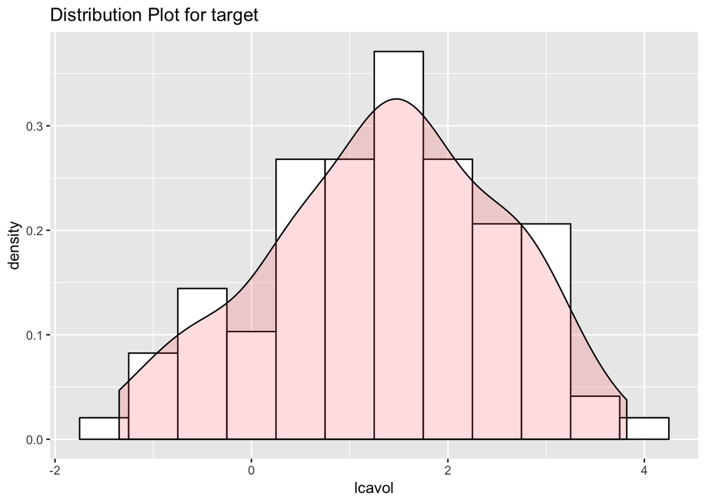

```r
#Before we start, check the distribution of target 'lcavol'
ggplot(Prostate, aes(x=lcavol)) +
  geom_histogram(aes(y=..density..),
                 binwidth=.5,
                 colour="black", fill="white") +
  geom_density(alpha=.2, fill="#FF6666")+
  ggtitle("Distribution Plot for target")
```

The distribution of lcavol is close to normal distirbution.

```r
X <- as.matrix(subset(Prostate,select = -lcavol))
#When set the left and right bounds same to the target, iregnet will perform lasso regression
Y <- as.matrix(cbind(Prostate['lcavol'],Prostate['lcavol']))
lasso.ire <- iregnet(x = X, y = Y, family = 'gaussian', alpha = 1)
lasso.glm <- glmnet(x = X, y = as.matrix(Prostate['lcavol']),
                    family = 'gaussian', alpha = 1)
```

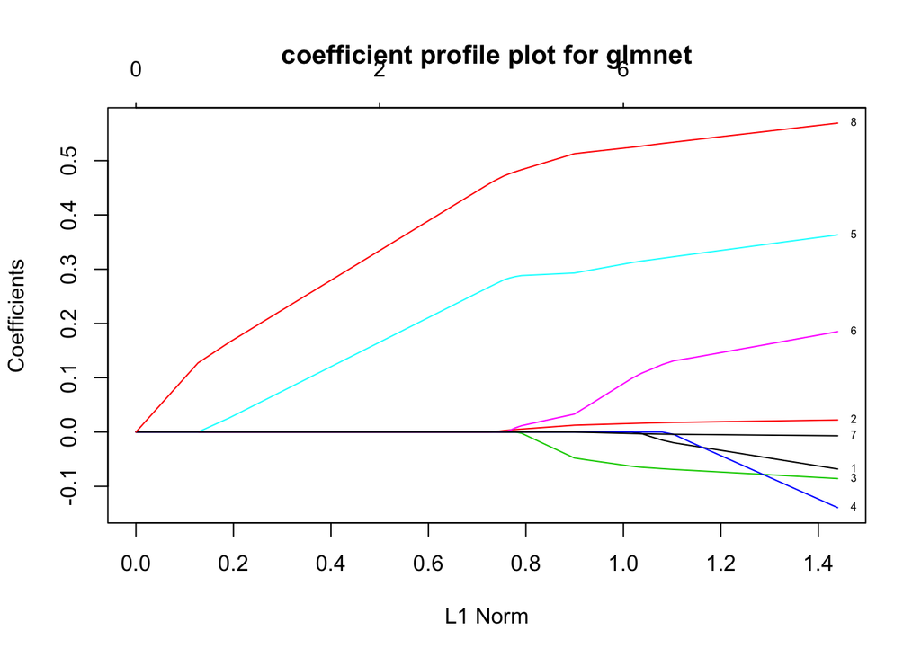

```r
plot(lasso.glm, label = T, main = 'coefficient profile plot for glmnet')
```

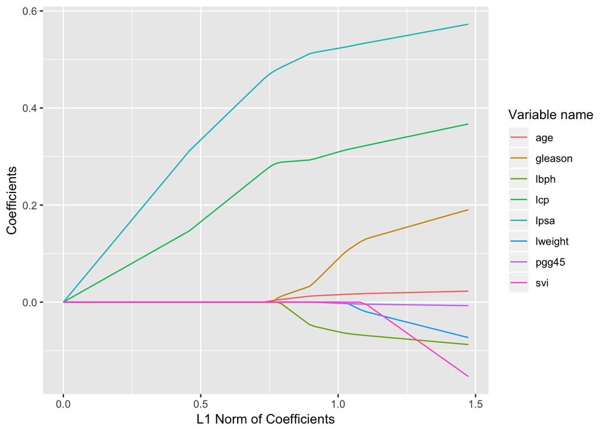

```r
plot(lasso.ire, main = 'coefficient profile plot for iregnet')
```

The two coefficient profile against L1 Norm of Coefficients plot are not exactly the same, but very close. We can say that they perform the same procedure.

### Test the efficiency of two function

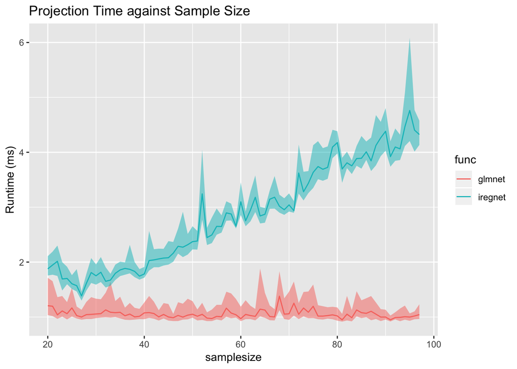

```r
idx = sample(array(1:nrow(X)))
#perform efficiency test on iregnet
eval.ire <- apply(array(20:nrow(X)),1,function(n){
  X.batch = X[idx[1:n],]
  Y.batch.ire = Y[idx[1:n],]
  #Y.batch.glm = as.matrix(Prostate['lcavol'])[idx[1:n]]
  time.ire = microbenchmark(iregnet(x = X.batch, y = Y.batch.ire),times = 100L, unit = 'ms')
  return(as.vector(summary(time.ire)[1,c('median','lq','uq')]))
  })
eval.ire <- data.frame(matrix(unlist(eval.ire), nrow=length(eval.ire), byrow=T))
colnames(eval.ire)<- c('median','lq','uq')
eval.ire$func <- 'iregnet'
eval.ire$samplesize <- (array(20:nrow(X)))

#perform efficiency test on glmnet
eval.glm <- apply(array(20:nrow(X)),1,function(n){
  X.batch = X[idx[1:n],]
  #Y.batch.ire = Y[idx[1:n],]
  Y.batch.glm = as.matrix(Prostate['lcavol'])[idx[1:n]]
  time.glm = microbenchmark(glmnet(x = X.batch, y = Y.batch.glm),times = 100L, unit = 'ms')
  return(as.vector(summary(time.glm)[1,c('median','lq','uq')]))
})
eval.glm <- data.frame(matrix(unlist(eval.glm), nrow=length(eval.glm), byrow=T))
colnames(eval.glm)<- c('median','lq','uq')
eval.glm$func <- 'glmnet'
eval.glm$samplesize <- (array(20:nrow(X)))
eval <- rbind(eval.glm,eval.ire)

p <- ggplot(eval, aes(samplesize))+
  geom_ribbon(aes(ymin=lq, ymax=uq,
                  fill=func, group=func), alpha=1/2)+
  geom_line(aes(y=median, group=func, colour=func))+
  ggtitle("Projection Time against Sample Size")+
  guides(fill="none")+
  ylab("Runtime (ms)")
p
```

It is obvious that the as the sample size increase for iregnet, time cost also increase. The increasing is linearity, which seems reasonable. However, the pattern for glmnet is different, time cost didn’t increase along with sample size.

To better prove the hypothesis, I repeat the Prostate data for 10 more times and add some noises to some columns to expend my samplesize. Below is the efficiency test for new dataset.

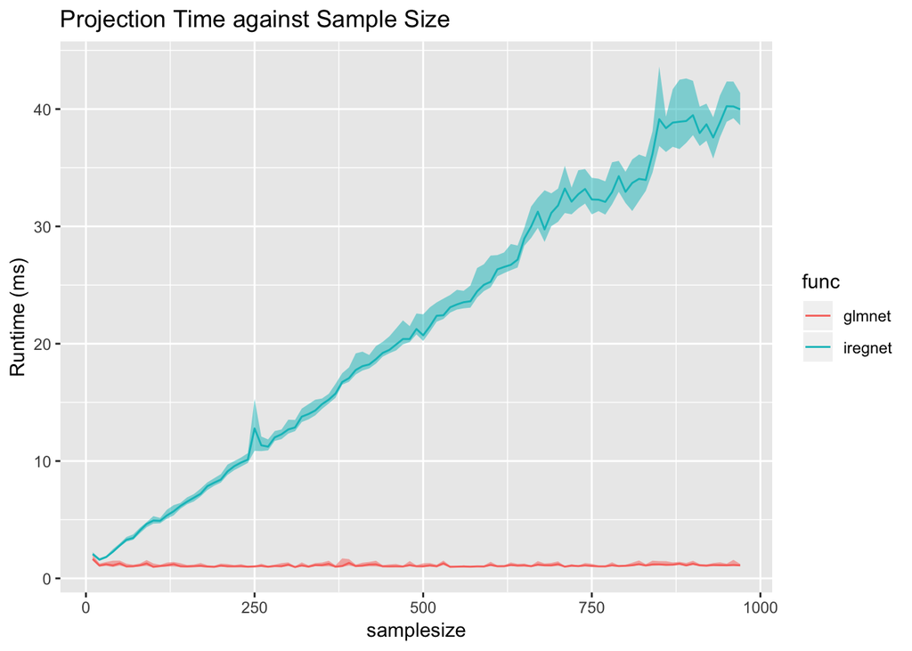

```r
#expend the dataset
Prostate.expend <- Prostate[rep(seq_len(nrow(Prostate)), 10), ]
Prostate.expend$lcavol <- Prostate.expend$lcavol+rnorm(nrow(Prostate.expend),0,0.1)
Prostate.expend$lweight <- Prostate.expend$lweight+rnorm(nrow(Prostate.expend),0,0.1)
Prostate.expend$lbph <-Prostate.expend$lbph+rnorm(nrow(Prostate.expend),0,0.1)
X <- as.matrix(subset(Prostate.expend,select = -lcavol))
Y <- as.matrix(cbind(Prostate.expend['lcavol'],Prostate.expend['lcavol']))
idx = sample(array(1:nrow(X)))

eval.ire <- apply(array(1:(nrow(X)/10))*10,1,function(n){

  X.batch = X[idx[1:n],]
  Y.batch.ire = Y[idx[1:n],]
  #cat(nrow(X.batch))
  #cat(' ')
  #Y.batch.glm = as.matrix(Prostate['lcavol'])[idx[1:n]]
  time.ire = microbenchmark(iregnet(x = X.batch, y = Y.batch.ire),times = 100L, unit = 'ms')
  return(as.vector(summary(time.ire)[1,c('median','lq','uq')]))
})
eval.ire <- data.frame(matrix(unlist(eval.ire), nrow=length(eval.ire), byrow=T))
colnames(eval.ire)<- c('median','lq','uq')
eval.ire$func <- 'iregnet'
eval.ire$samplesize <- array(1:(nrow(X)/10))*10

eval.glm <- apply(array(1:(nrow(X)/10))*10,1,function(n){
  X.batch = X[idx[1:n],]
  #cat(n)
  #cat(' ')
  #Y.batch.ire = Y[idx[1:n],]
  Y.batch.glm = as.matrix(Prostate.expend['lcavol'])[idx[1:n]]
  time.glm = microbenchmark(glmnet(x = X.batch, y = Y.batch.glm),times = 100L, unit = 'ms')
  return(as.vector(summary(time.glm)[1,c('median','lq','uq')]))
})
eval.glm <- data.frame(matrix(unlist(eval.glm), nrow=length(eval.glm), byrow=T))
colnames(eval.glm)<- c('median','lq','uq')
eval.glm$func <- 'glmnet'
eval.glm$samplesize <- array(1:(nrow(X)/10))*10
eval <- rbind(eval.glm,eval.ire)

p <- ggplot(eval, aes(samplesize))+
  geom_ribbon(aes(ymin=lq, ymax=uq,
                  fill=func, group=func), alpha=1/2)+
  geom_line(aes(y=median, group=func, colour=func))+
  ggtitle("Projection Time against Sample Size")+
  guides(fill="none")+
  ylab("Runtime (ms)")
p
```

This test prove my hypothesis. The time cost of glmnet didn’t change to much with the increase of sample size. What if I increase the sample size to 100,000? This time I also run the test on glmnet

```r
#expend the dataset
Prostate.expend <- Prostate[rep(seq_len(nrow(Prostate)), 1000), ]
Prostate.expend$lcavol <- Prostate.expend$lcavol+rnorm(nrow(Prostate.expend),0,0.1)
Prostate.expend$lweight <- Prostate.expend$lweight+rnorm(nrow(Prostate.expend),0,0.1)
Prostate.expend$lbph <-Prostate.expend$lbph+rnorm(nrow(Prostate.expend),0,0.1)
X <- as.matrix(subset(Prostate.expend,select = -lcavol))

idx = sample(array(1:nrow(X)))

eval.glm <- apply(array(1:(nrow(X)/2000))*2000,1,function(n){
  X.batch = X[idx[1:n],]
  cat(n)
  cat(' ')
  #Y.batch.ire = Y[idx[1:n],]
  Y.batch.glm = as.matrix(Prostate.expend['lcavol'])[idx[1:n]]
  time.glm = microbenchmark(glmnet(x = X.batch, y = Y.batch.glm),times = 100L, unit = 'ms')
  return(as.vector(summary(time.glm)[1,c('median','lq','uq')]))
})
```

```
## 2000 4000 6000 8000 10000 12000 14000 16000 18000 20000 22000 24000 26000 28000 30000 32000 34000 36000 38000 40000 42000 44000 46000 48000 50000 52000 54000 56000 58000 60000 62000 64000 66000 68000 70000 72000 74000 76000 78000 80000 82000 84000 86000 88000 90000 92000 94000 96000
```

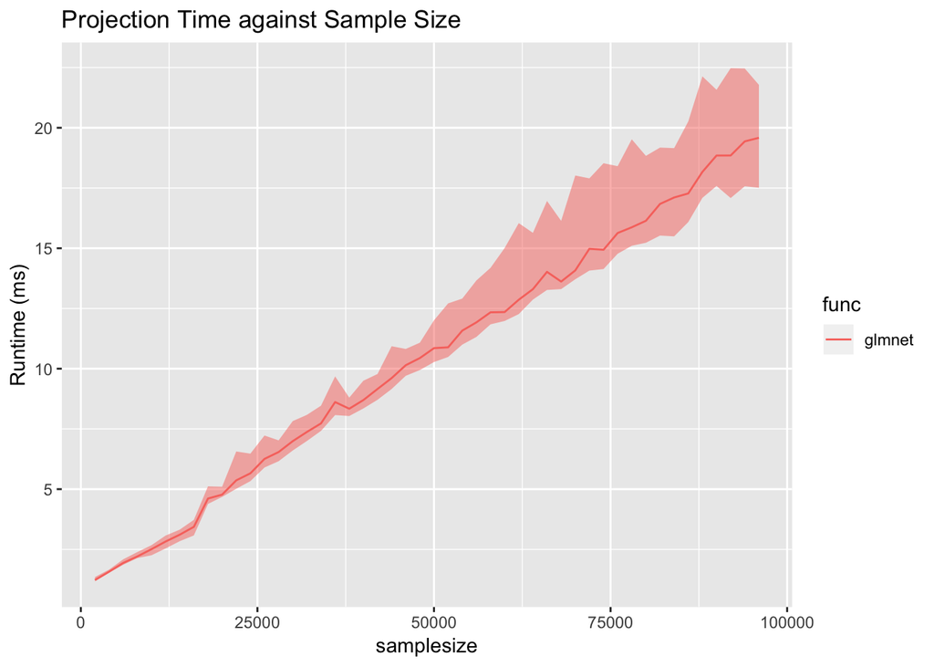

```r
eval.glm <- data.frame(matrix(unlist(eval.glm), nrow=length(eval.glm), byrow=T))
colnames(eval.glm)<- c('median','lq','uq')
eval.glm$func <- 'glmnet'
eval.glm$samplesize <- array(1:(nrow(X)/2000))*2000

p <- ggplot(eval.glm, aes(samplesize))+
  geom_ribbon(aes(ymin=lq, ymax=uq,
                  fill=func, group=func), alpha=1/2)+
  geom_line(aes(y=median, group=func, colour=func))+
  ggtitle("Projection Time against Sample Size")+
  guides(fill="none")+
  ylab("Runtime (ms)")
p
```

The running time still increase in a larger scale sample size for glmnet.